# Rank-normalized split-Rhat and relative efficiency estimates

The total energy of HMC should affect how far in the tails a chain in one iteration can go. Fat tails of the target have high energy, and thus only chains with high total energy can reach there. This will suggest that the random walk in total energy would cause random walk in the variance of $x$. Let’s check the second moment of $x$.

```r
samp_x2 <- as.array(fit_n, pars = "x")^2
res <- monitor_extra(samp_x2)
print(res)
```

```
Inference for the input samples (4 chains: each with iter = 10000; warmup = 0):

      mean se_mean   sd Q5  Q50  Q95  neff reff sneff zneff zsneff zsreff Rhat sRhat zRhat zsRhat
x[1]  1.01    0.01 1.44  0 0.46 3.85 14657 0.37 14664 16440  16443   0.41    1     1     1      1
x[2]  0.99    0.01 1.42  0 0.44 3.80 15511 0.39 15518 16488  16492   0.41    1     1     1      1
x[3]  0.98    0.01 1.39  0 0.45 3.80 14684 0.37 14703 16133  16148   0.40    1     1     1      1
x[4]  1.01    0.01 1.46  0 0.45 3.95 14510 0.36 14518 16039  16070   0.40    1     1     1      1
x[5]  1.00    0.01 1.42  0 0.45 3.86 15017 0.38 15029 16766  16785   0.42    1     1     1      1
x[6]  1.00    0.01 1.42  0 0.45 3.91 14368 0.36 14380 16547  16572   0.41    1     1     1      1
x[7]  0.99    0.01 1.39  0 0.45 3.74 15464 0.39 15488 17080  17097   0.43    1     1     1      1
x[8]  1.00    0.01 1.42  0 0.46 3.80 14773 0.37 14766 16397  16397   0.41    1     1     1      1
x[9]  1.00    0.01 1.41  0 0.45 3.81 13439 0.34 13467 15910  15922   0.40    1     1     1      1
x[10] 0.98    0.01 1.39  0 0.44 3.73 14654 0.37 14672 16430  16461   0.41    1     1     1      1
x[11] 1.00    0.01 1.41  0 0.46 3.85 15068 0.38 15098 15997  16008   0.40    1     1     1      1
x[12] 0.99    0.01 1.41  0 0.45 3.75 14215 0.36 14221 15342  15368   0.38    1     1     1      1
x[13] 0.98    0.01 1.38  0 0.44 3.83 13548 0.34 13547 15368  15371   0.38    1     1     1      1
x[14] 0.98    0.01 1.37  0 0.45 3.75 14547 0.36 14565 16418  16461   0.41    1     1     1      1
x[15] 0.98    0.01 1.38  0 0.45 3.77 15417 0.39 15414 16652  16655   0.42    1     1     1      1
x[16] 1.01    0.01 1.41  0 0.47 3.86 15551 0.39 15561 16390  16400   0.41    1     1     1      1
      zfsRhat zfsneff zfsreff medsneff medsreff madsneff madsreff
x[1]        1   18445    0.46    19172     0.48    23268     0.58
x[2]        1   19699    0.49    19309     0.48    24908     0.62
x[3]        1   18532    0.46    18694     0.47    23865     0.60
x[4]        1   18983    0.47    19156     0.48    23907     0.60
x[5]        1   19535    0.49    20102     0.50    25043     0.63
x[6]        1   17535    0.44    19596     0.49    22613     0.57
x[7]        1   19019    0.48    19555     0.49    23336     0.58
x[8]        1   18920    0.47    18816     0.47    24195     0.60
x[9]        1   18386    0.46    18674     0.47    22198     0.55
x[10]       1   18570    0.46    19147     0.48    23900     0.60
x[11]       1   19482    0.49    18393     0.46    24709     0.62
x[12]       1   18691    0.47    18588     0.46    23963     0.60
x[13]       1   18506    0.46    18258     0.46    24132     0.60
x[14]       1   18823    0.47    19062     0.48    23428     0.59
x[15]       1   19633    0.49    19620     0.49    24476     0.61
x[16]       1   20083    0.50    18829     0.47    24441     0.61
```

The mean of the bulk-$R_{\rm eff}$ for $x_j^2$ is 0.41, which is quite close to the bulk-$R_{\rm eff}$ for `lp__`. This is not that surprising as the potential energy in normal model is proportional to $\sum_{j=1}^J x_j^2$.

Let’s check the relative efficiency in different parts of the posterior by computing the relative efficiency of small interval probability estimates for `x[1]^2`.

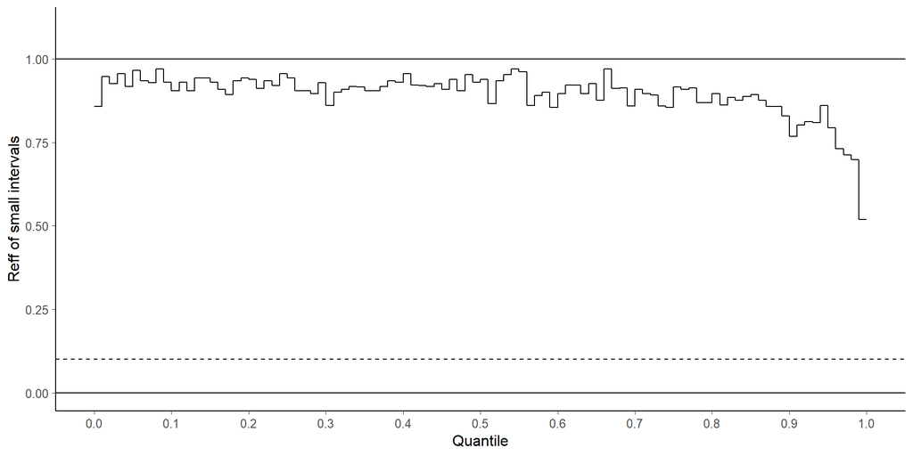

```r
plot_local_reff(fit = samp_x2, par = 1, nalpha = 100)
```

The relative efficiency is mostly a bit below 1, but for the right tail of $x_1^2$ the relative efficiency drops. This is likely due to only some iterations having high enough total energy to obtain draws from the high energy part of the tail. Let’s check the relative efficiency of quantiles.

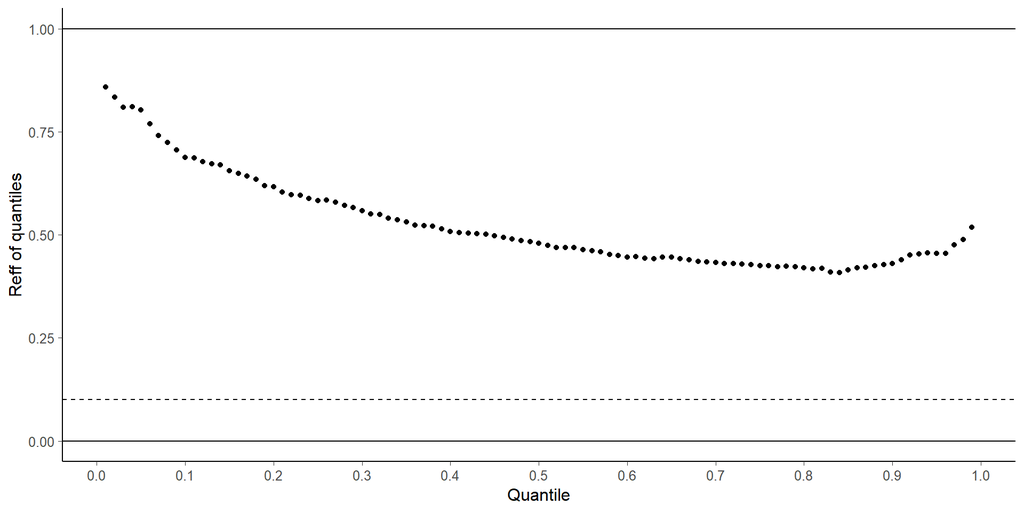

```r
plot_quantile_reff(fit = samp_x2, par = 1, nalpha = 100)
```

We can see the correlation between `lp__` and magnitude of `x[1]` in the following plot.

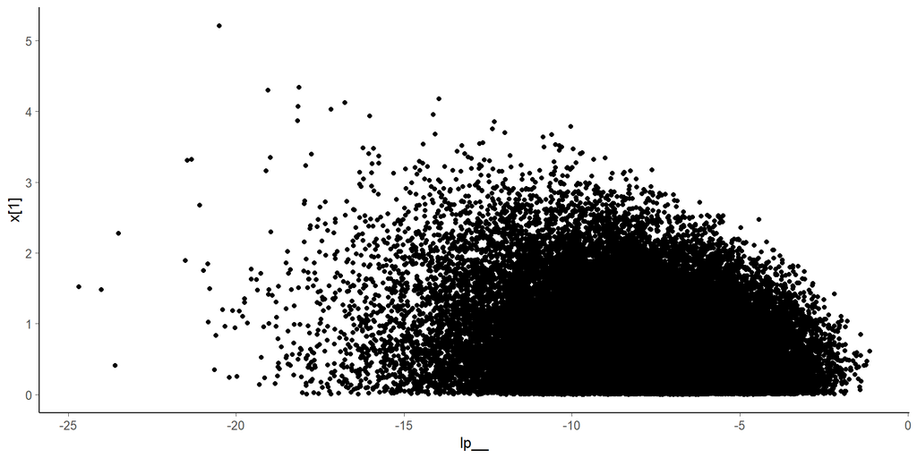

```r
samp <- as.array(fit_n)
qplot(
  as.vector(samp[, , "lp__"]),
  abs(as.vector(samp[, , "x[1]"]))
) +
  labs(x = 'lp__', y = 'x[1]')
```

Low `lp__` values corresponds to high energy and more variation in `x[1]`, and high `lp__` corresponds to low energy and small variation in `x[1]`. Finally $\sum_{j=1}^J x_j^2$ is perfectly correlated with `lp__`.

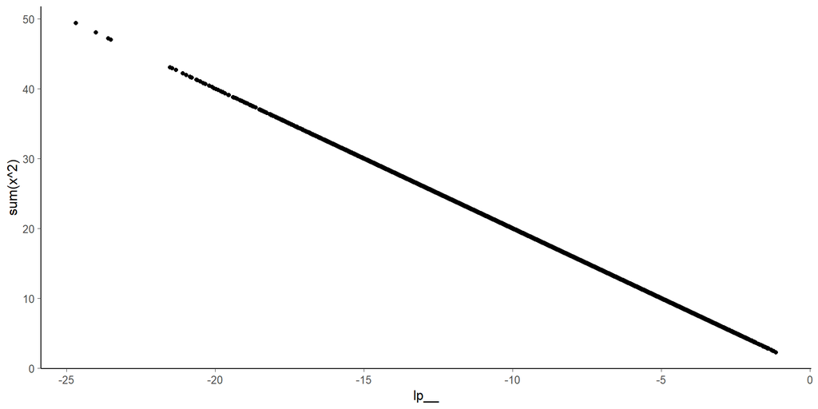

```r
qplot(
  as.vector(samp[, , "lp__"]),
  as.vector(apply(samp[, , 1:16]^2, 1:2, sum))
) +
  labs(x = 'lp__', y = 'sum(x^2)')
```

This shows that even if we get high relative efficiency estimates for central quantities (like mean or median), it is important to look at the relative efficiency of scale and tail quantities, as well. The relative efficiency of `lp__` can also indicate problems of sampling in the tails.

# Original Computing Environment

```r
makevars <- file.path(Sys.getenv("HOME"), ".R/Makevars")
if (file.exists(makevars)) {
  writeLines(readLines(makevars))
}
```

```
CXX14FLAGS=-O3 -Wno-unused-variable -Wno-unused-function
CXX14 = $(BINPREF)g++ -m$(WIN) -std=c++1y
CXX11FLAGS=-O3 -Wno-unused-variable -Wno-unused-function
```